# Ethogram Data Collection 1 - Outcome (Success, Fail)

Marinara Marcato

# 1 Introduction

This document shows the data analysis carried out to investigate the association between ethogram scores filled out by two trainers and the dog’s training outcome. Statistical methods will be used to test the hypothesis that there is a relationship between ethogram scores at DC1 and training outcome (Success, Fail).

# 2 Data Exploration

The dataset comprised of the following types and number of variables. The original ethogram items contained ordinal and categorical variables. The score variables were numerical derived from the original ethogram items.

```
##
## categorical    comments        info     ordinal       score        time
##          17          16          17          53          42          25
##      unused
##          11
```

All ordinal (n=53) and categorical (n=17) variables from the original ethogram items, score (n = 42) variables derived from the original ethogram items and demographical variables (n=2) - namely, Sex and Breed - will be analysed.

## 2.1 Demographics

Overview of the dogs participating in the data collection. Inclusion criteria: only Labrador Retrievers (LR) and Labrador Retrievers crossed with Golden Retrievers (LRxGR) were kept for data analysis.

```
## Original:  101 116
```

```
##
##        GR GRxPoodle        LR       LRx     LRxGR
##         1         1        45        13        41
```

```
##
##    LR LRxGR
##    45    54
```

```
## Updated:  99 116
```

```
##
## Success    Fail
##      79      20
```

```
##
##   Success      Fail
## 0.7979798 0.2020202
```

```
##
##  F  M
## 49 50
```

Calculate descriptive statistics for age at arrival at the training centre for formal training. Calculate descriptive statistics for age at assessment when the dogs performed the behaviour test at data collection 1, which should be around week 3 of formal training.

```
## Age at Arrival: Mean 15.26 Standard Deviation 2.03
```

```
## Age at Assessment: Mean 16.12 Standard Deviation 2.01
```

Calculate statistics of duration of training for the dogs that were withdrawn from training. Performing this behaviour test at the beginning on the training (Week 3) would allow assistance dog training organisations to understand which dog are more suitable and allow them to make informed decisions when analysing which dogs to keep for training considering the results of this objective assessment.

```
## [1] "Duration of Training in weeks"
```

```
##     Duration
##  Min.   : 1.143
##  1st Qu.: 9.000
##  Median :14.429
##  Mean   :15.064
##  3rd Qu.:18.357
##  Max.   :31.143
```

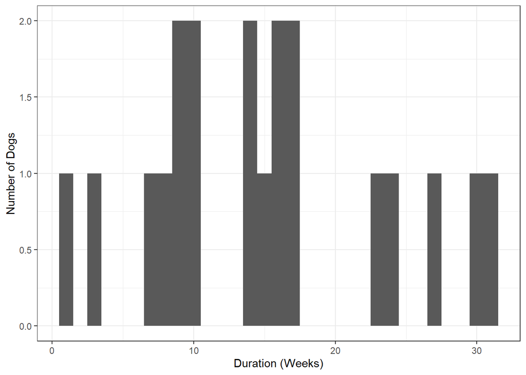

## 2.2 Univariate Logistic regression

Variables whose logistic regression model resulted in p<0.2 when used to predict Outcome are shown. Positive estimates increase the probability of failure, while negative estimates decrease the probability of failure.

Categorical: 1 out of 17 ethogram items, 1 out of 2 demographics variables (Sex and Breed).

```
##                                        estimate_1  p_value_1
## Tea.Towel.First.Response..Indifferent.   1.098612 0.11768247
## Breed                                   -1.003451 0.05448661
```

```
## Categorical variable with 4 factors: Both Left None Righ
```

```
## $Kong.Interaction.Lateralisation
##
## Call:
## glm(formula = Outcome ~ x, family = binomial(link = logit), data = dc_cat,
##     na.action = na.exclude)
##
## Deviance Residuals:
##     Min       1Q   Median       3Q      Max
## -0.8346  -0.7981  -0.5482  -0.4590   2.1460
##
## Coefficients:
##             Estimate Std. Error z value Pr(>|z|)
## (Intercept)  -2.1972     1.0540  -2.085   0.0371 *
## xLeft         1.3218     1.1808   1.119   0.2630
## xNone         0.3781     1.1422   0.331   0.7406
## xRigh         1.2164     1.1576   1.051   0.2934
## ---
## Signif. codes:  0 '***' 0.001 '**' 0.01 '*' 0.05 '.' 0.1 ' ' 1
##
## (Dispersion parameter for binomial family taken to be 1)
##
##     Null deviance: 90.954  on 91  degrees of freedom
## Residual deviance: 87.635  on 88  degrees of freedom
##   (7 observations deleted due to missingness)
## AIC: 95.635
##
## Number of Fisher Scoring iterations: 4
```

Ordinal: 7 out of 53 ethogram items. Score: 10 out of 42 variables.

```
##                                               estimate_1 p_value_1
## Lying.Settled                                     0.3347    0.1950
## Body.check.Table                                 -0.5755    0.0316
## Crate.Behaviours..Sniffing.Exploring..            0.4149    0.1775
## Crate.Behaviours..Actively.Seeking.Attention.    -0.3379    0.1556
## Crate.Behaviours..Nudging.Crate.                  0.5827    0.1826
## Petting.Confidence.During                        -0.6038    0.0435
## Petting.Responsiveness.After                     -0.3942    0.1754
## S.Walking.Distractions.Pull_prod                 -0.0640    0.1773
## S.Sensitivity_mean                               -2.3043    0.0057
## S.Kong.Response_prod                              0.0056    0.1976
## S.Crate.Stimulus_mean                             0.8758    0.1223
## S.Crate.Handler_mean                             -0.4020    0.1997
## S.Crate.Handler_prod                             -0.0352    0.1765
## S.Petting.Stimulus.During_mean                   -1.0546    0.0466
## S.Petting.Stimulus.During_prod                   -0.2282    0.1680
## S.Petting.Engagement.During_mean                 -0.8025    0.1532
## S.Sociability_mean                               -0.6653    0.0961
```

## 2.3 Feature Selection

Selected features based on the univariate logistic regression model results. Whenever both the scores and their original items had p<0.2, the original variables was removed and the scores with lowest p value were kept.

```
##  [1] "Lying.Settled"
##  [2] "S.Walking.Distractions.Pull_prod"
##  [3] "S.Sensitivity_mean"
##  [4] "S.Kong.Response_prod"
##  [5] "S.Crate.Stimulus_mean"
##  [6] "S.Crate.Handler_prod"
##  [7] "S.Sociability_mean"
##  [8] "Tea.Towel.First.Response..Indifferent."
##  [9] "Breed"
## [10] "Outcome"
```

## 2.4 Missing Data

DC1, missing values per column and per row. Very few data are missing considering the original items selected.

```
##                          Lying.Settled       S.Walking.Distractions.Pull_prod
##                                      2                                      0
##                     S.Sensitivity_mean                   S.Kong.Response_prod
##                                      0                                      0
##                  S.Crate.Stimulus_mean                   S.Crate.Handler_prod
##                                      2                                      0
##                     S.Sociability_mean Tea.Towel.First.Response..Indifferent.
##                                      0                                      1
##                                  Breed                                Outcome
##                                      0                                      0
```

```
## dc_row_nas
##  0  1
## 94  5
```

## 2.5 Visualization

I think for the factors, because they are continuous variables (average of discrete variables), it is better to only have the boxplot.

```
## Plot these features manually:  Tea.Towel.First.Response..Indifferent. Breed
```

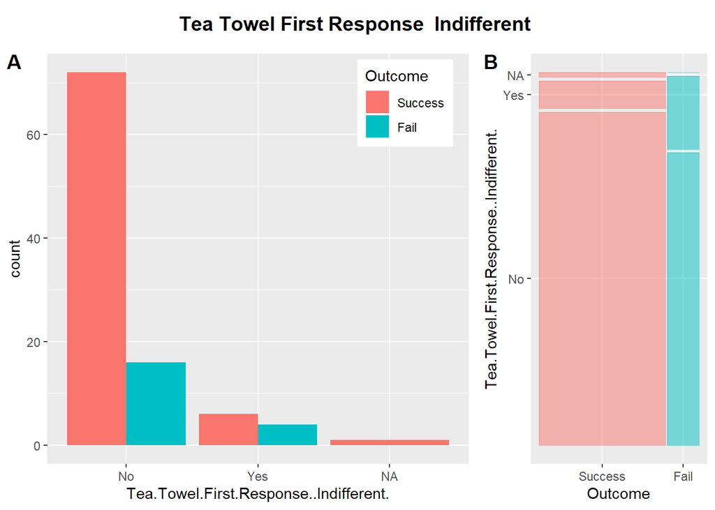

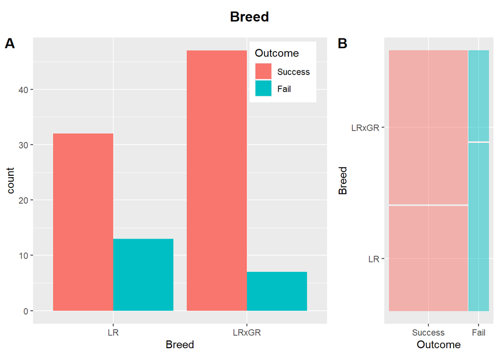

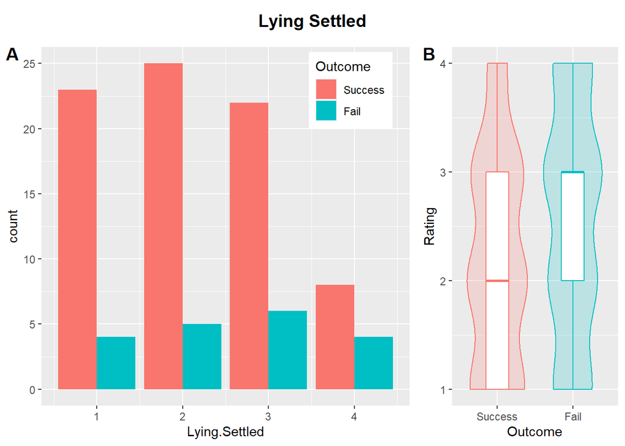

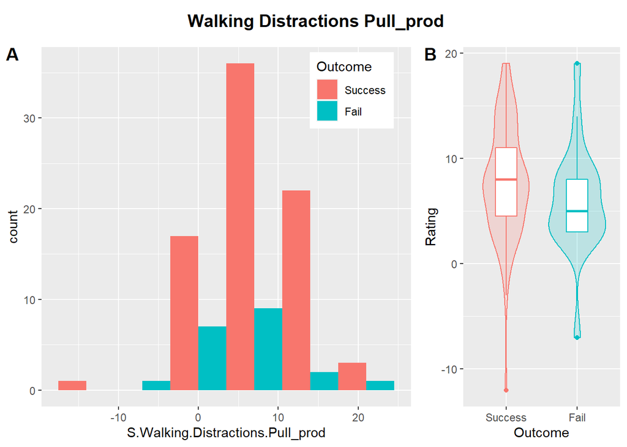

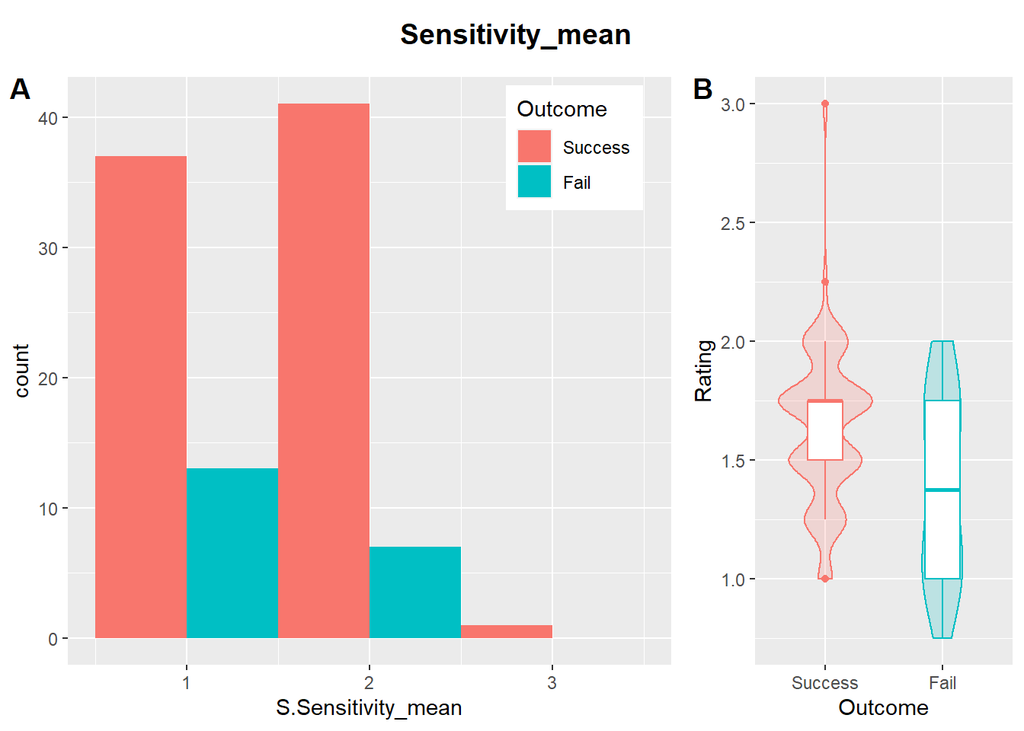

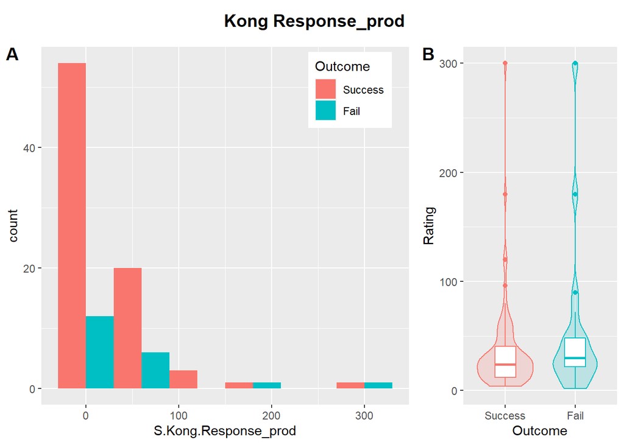

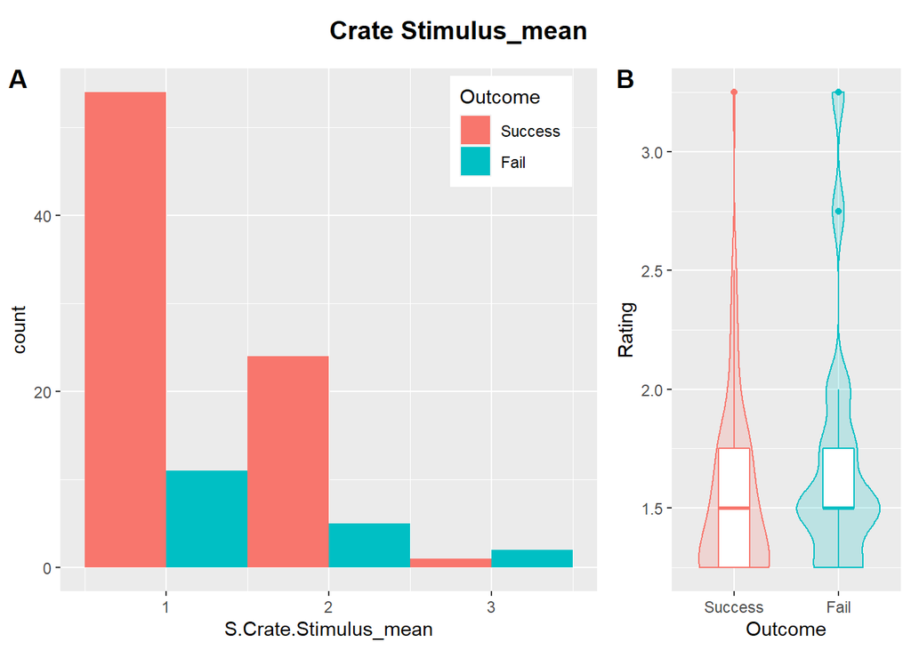

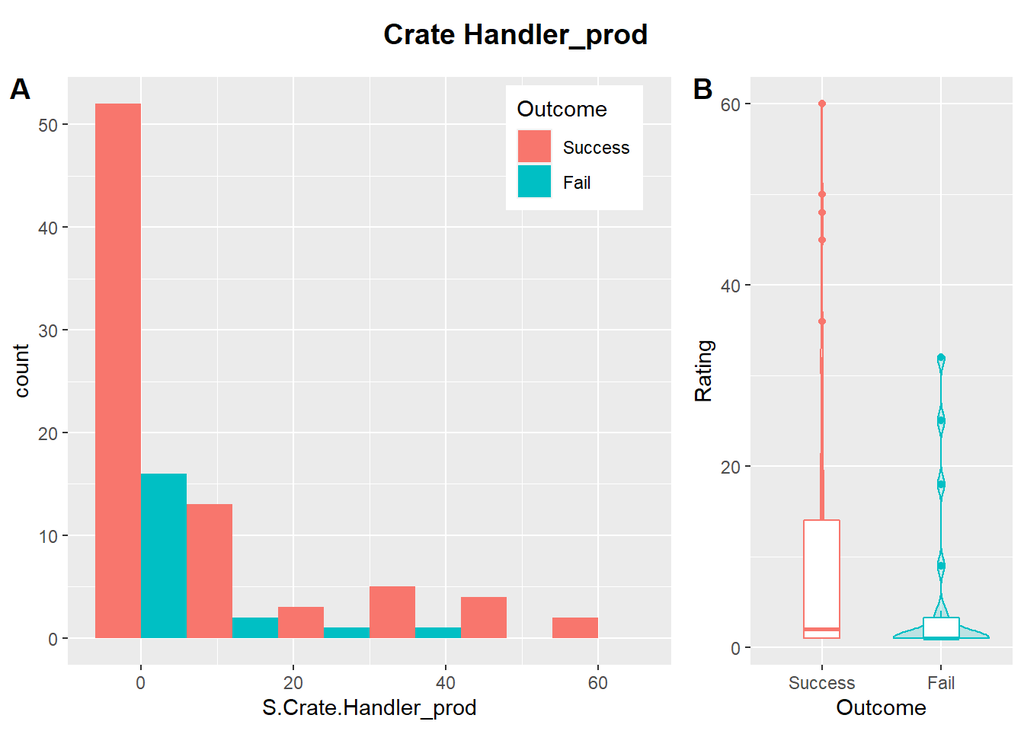

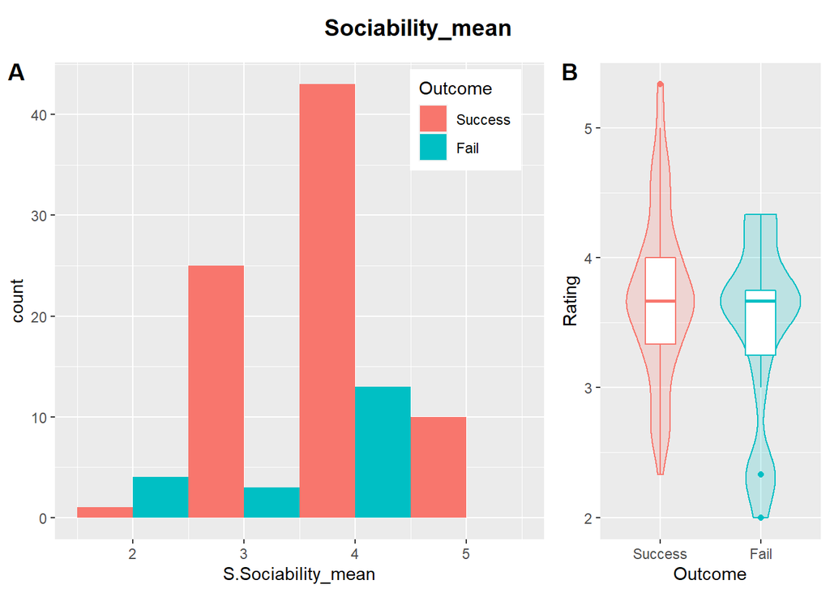

## 2.6 Multicollinearity

The Variance Inflation Factor (VIF) was calculate to assess multicollinearity. VIF = 1 no correlation, 5 < VIF < 10 moderate correlation, VIF > 10 high multicollinearity. VIF larger than 5 or 10 is large and indicate a high level of multicollinearity and should be further processed.

```
##
## Call:
## glm(formula = Outcome ~ ., family = binomial(link = logit), data = dc_sign)
##
## Deviance Residuals:
##     Min       1Q   Median       3Q      Max
## -1.4024  -0.5687  -0.3727  -0.1386   2.2645
##
## Coefficients:
##                                            Estimate Std. Error z value Pr(>|z|)
## (Intercept)                                2.766349   3.092002   0.895   0.3710
## Lying.Settled                              0.452683   0.347553   1.302   0.1928
## S.Walking.Distractions.Pull_prod          -0.088264   0.073173  -1.206   0.2277
## S.Sensitivity_mean                        -2.346531   1.055314  -2.224   0.0262
## S.Kong.Response_prod                       0.011535   0.005526   2.087   0.0369
## S.Crate.Stimulus_mean                      1.141865   0.812479   1.405   0.1599
## S.Crate.Handler_prod                      -0.032654   0.030678  -1.064   0.2871
## S.Sociability_mean                        -0.756006   0.520672  -1.452   0.1465
## Tea.Towel.First.Response..Indifferent.Yes  0.223014   0.926812   0.241   0.8098
## BreedLRxGR                                -1.299595   0.709594  -1.831   0.0670
##
## (Intercept)
## Lying.Settled
## S.Walking.Distractions.Pull_prod
## S.Sensitivity_mean                        *
## S.Kong.Response_prod                      *
## S.Crate.Stimulus_mean
## S.Crate.Handler_prod
## S.Sociability_mean
## Tea.Towel.First.Response..Indifferent.Yes
## BreedLRxGR                                .
## ---
## Signif. codes:  0 '***' 0.001 '**' 0.01 '*' 0.05 '.' 0.1 ' ' 1
##
## (Dispersion parameter for binomial family taken to be 1)
##
##     Null deviance: 88.864  on 93  degrees of freedom
## Residual deviance: 66.634  on 84  degrees of freedom
##   (5 observations deleted due to missingness)
## AIC: 86.634
##
## Number of Fisher Scoring iterations: 6
```

```
##                          Lying.Settled       S.Walking.Distractions.Pull_prod
##                               1.211387                               1.239232
##                     S.Sensitivity_mean                   S.Kong.Response_prod
##                               1.176454                               1.230296
##                  S.Crate.Stimulus_mean                   S.Crate.Handler_prod
##                               1.156301                               1.217108
##                     S.Sociability_mean Tea.Towel.First.Response..Indifferent.
##                               1.072839                               1.181385
##                                  Breed
##                               1.202288
```

# 3 Multivariate Model

## 3.1 Preprocessing: Normalization + Imputation + PCA

## 3.2 Recursive Feature Elimination (RFE) + Multivariate Logistic Regression (LR)

```
## [1] "Original dataset"
```

```
## 'data.frame':    99 obs. of  10 variables:
##  $ Lying.Settled                         : num  2 1 3 2 1 2 1 NA 4 3 ...
##  $ S.Walking.Distractions.Pull_prod      : num  4 8 3 7 8 19 14 14 14 8 ...
##  $ S.Sensitivity_mean                    : num  1 1.5 1 1.75 1.75 1.25 1.25 2 1 2 ...
##  $ S.Kong.Response_prod                  : num  12 180 12 12 24 30 64 24 24 48 ...
##  $ S.Crate.Stimulus_mean                 : num  1.75 1.5 1.5 1.25 1.75 1.25 1.25 1.75 1.75 1.25 ...
##  $ S.Crate.Handler_prod                  : num  1 3 18 1 4 36 32 2 1 1 ...
##  $ S.Sociability_mean                    : num  3.67 4.33 3.67 3.33 5 ...
##  $ Tea.Towel.First.Response..Indifferent.: Factor w/ 2 levels "No","Yes": 1 1 1 1 1 1 1 1 2 1 ...
##  $ Breed                                 : Factor w/ 2 levels "LR","LRxGR": 2 2 2 1 2 2 1 1 1 2 ...
##  $ Outcome                               : Factor w/ 2 levels "Success","Fail": 1 2 2 1 1 1 1 1 2 1 ...
```

```
## [1] "PCA dataset after keeping 95% variance"
```

```
## tibble [99 × 9] (S3: tbl_df/tbl/data.frame)
##  $ Outcome: Factor w/ 2 levels "Success","Fail": 1 2 2 1 1 1 1 1 2 1 ...
##  $ PC1    : num [1:99] 1.211 -2.323 1.484 -0.049 -1.266 ...
##  $ PC2    : num [1:99] 0.0657 0.425 0.3787 -0.8684 -0.5334 ...
##  $ PC3    : num [1:99] -0.381 -1.309 0.547 -0.133 0.821 ...
##  $ PC4    : num [1:99] 0.524 -0.303 0.239 -0.347 1.082 ...
##  $ PC5    : num [1:99] 1.203 1.626 0.908 -0.556 0.758 ...
##  $ PC6    : num [1:99] 0.42 -0.55 0.882 0.62 -0.916 ...
##  $ PC7    : num [1:99] -0.882 0.283 0.282 -0.481 -1.271 ...
##  $ PC8    : num [1:99] 0.918 1.305 1.178 -0.142 0.771 ...
```

```
## [1] "Modelling using Recursive Feature Elimination (RFE) to optimize for AUC-ROC using Leave One Out Cross-Validation (LOOCV)"
```

```
##
## Recursive feature selection
##
## Outer resampling method: Leave-One-Out Cross-Validation
##
## Resampling performance over subset size:
##
##  Variables    ROC   Sens Spec Selected
##          1 0.6715 0.9873 0.05
##          2 0.6987 0.9747 0.25
##          3 0.7127 0.9241 0.20
##          4 0.7234 0.9241 0.20
##          5 0.7475 0.9494 0.35        *
##          6 0.7196 0.9367 0.35
##          7 0.7310 0.9494 0.35
##          8 0.7209 0.9494 0.35
##
## The top 5 variables (out of 5):
##    PC1, PC3, PC5, PC7, PC8
##
##
## Call:
## glm(formula = Class ~ ., family = "binomial", data = tmp)
##
## Deviance Residuals:
##      Min        1Q    Median        3Q       Max
## -1.52477  -0.59313  -0.32271  -0.09305   2.39024
##
## Coefficients:
##             Estimate Std. Error z value Pr(>|z|)
## (Intercept)  -1.3110     0.4165  -3.148  0.00164 **
## PC1           0.9705     0.3191   3.042  0.00235 **
## PC3          -1.0064     0.3479  -2.893  0.00382 **
## PC5           0.8432     0.3687   2.287  0.02221 *
## PC7           0.9185     0.4419   2.078  0.03767 *
## PC8          -1.1079     0.6441  -1.720  0.08541 .
## ---
## Signif. codes:  0 '***' 0.001 '**' 0.01 '*' 0.05 '.' 0.1 ' ' 1
##
## (Dispersion parameter for binomial family taken to be 1)
##
##     Null deviance: 99.632  on 98  degrees of freedom
## Residual deviance: 72.206  on 93  degrees of freedom
## AIC: 84.206
##
## Number of Fisher Scoring iterations: 6
```

```
##
## deviance difference:  27.42594
## df difference:  5
## level of significance:  0.9999529
## the model is a good fit:  TRUE
```

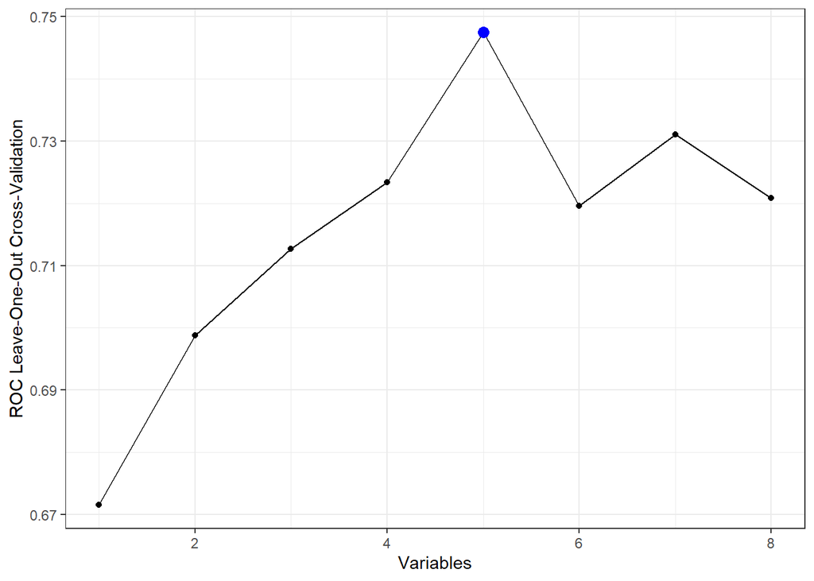

## 3.3 Interpretation

```
## [1] "Results from the model created"
```

```
##               Estimate Std. Error   z value    Pr(>|z|)        OR      2.5 %
## (Intercept) -1.3110333  0.4164522 -3.148100 0.001643352 0.2695414 0.11103478
## PC1          0.9705272  0.3190610  3.041824 0.002351497 2.6393355 1.48793353
## PC3         -1.0063623  0.3478601 -2.893009 0.003815703 0.3655463 0.17145894
## PC5          0.8431598  0.3687223  2.286707 0.022212938 2.3236977 1.17004887
## PC7          0.9184922  0.4419133  2.078445 0.037668436 2.5055097 1.07604361
## PC8         -1.1079329  0.6441035 -1.720116 0.085411290 0.3302409 0.08464217
##                97.5 %
## (Intercept) 0.5797140
## PC1         5.2628978
## PC3         0.6842986
## PC5         5.0560011
## PC7         6.2311796
## PC8         1.1039778
```

```
## [1] "Probability predicted by the LR using DC1 ethogram data vs true Outcome"
```

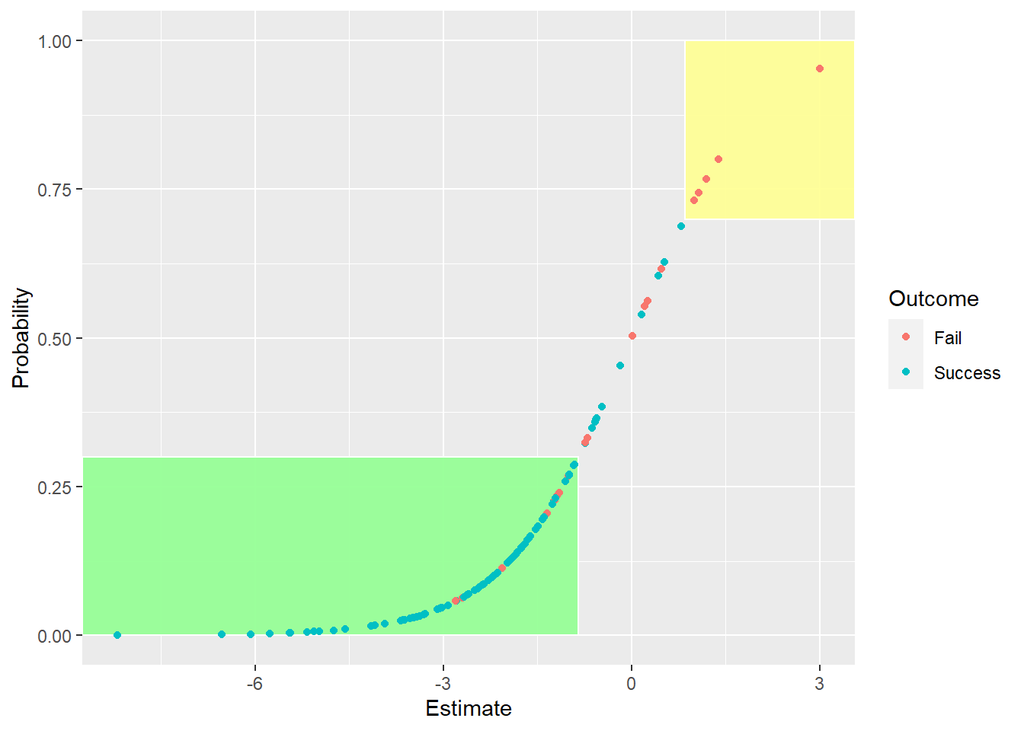

```
## [1] "Probability predicted by the LR using DC1 ethogram data vs true Status"
```

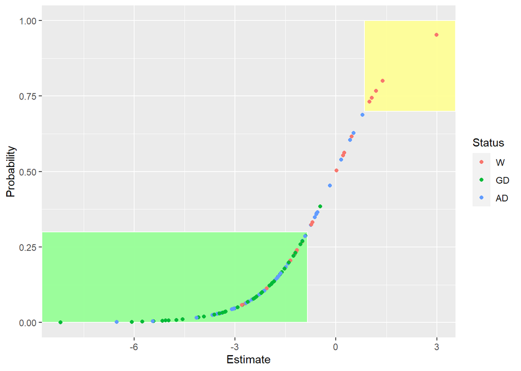

```
## Predicted probability < 0.3  -> Green flag
```

```
## [1] "Dogs flagged green are likely to SUCCEED, true outcome count and status proportion:"
```

```
##
##    Fail Success
##       9      68
```

```
##
##         W        GD        AD
## 0.1168831 0.5454545 0.3376623
```

```
## Predicted probability > 0.7 -> Yellow flag
```

[output not shown]

```
##
##    Fail Success
##       5       0
```

```
##
##  W GD AD
##  1  0  0
```

## 3.4 Feature Importance

### 3.4.1 Explained variance

```
## PCA features kept in the final model after RFE:  PC1 PC3 PC5 PC7 PC8
```

```
## [1] "Explained Variance per Principal Component (Scree Plot)"
```

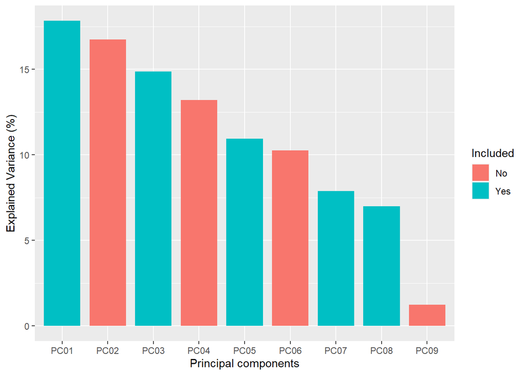

### 3.4.2 Coefficient loadings

```
##                                        terms       value
## 1                                Breed_LRxGR  0.94574088
## 2                              Lying.Settled  0.56467015
## 3           S.Walking.Distractions.Pull_prod -0.46851985
## 4                       S.Kong.Response_prod  0.17718957
## 5                       S.Crate.Handler_prod -0.13522549
## 6                      S.Crate.Stimulus_mean -0.06670279
## 7                         S.Sensitivity_mean  0.06091831
## 8                         S.Sociability_mean -0.02833990
## 9 Tea.Towel.First.Response..Indifferent._Yes -0.01273871
```

```
## Principal Component PC1 PC3 PC5 PC7 PC8 vs Original Variables
```

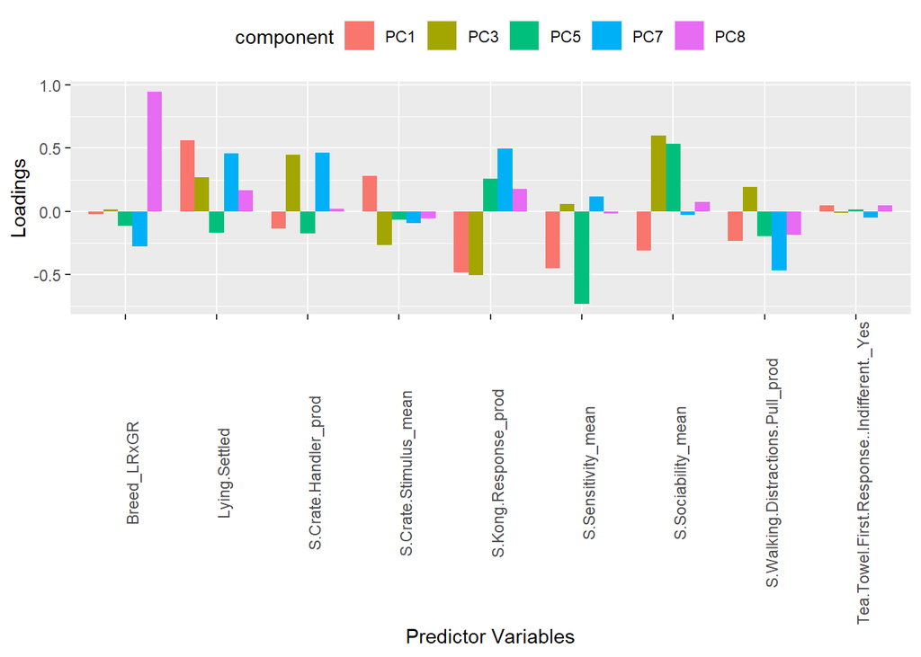

# 4 Conclusion